# Principal Components Regression; Partial Least Squares Regression

STA 206 | Fall 2021

November 29, 2021

When there are a large number of highly intercorrelated X variables, one strategy is to produce a (much) smaller number of linear combinations of the original variables that are orthogonal to each other, and then use these new variables in place of the original X variables in the regression. We will discuss two such methods, namely, *principal component regression (PCR)* and *partial least squares regression (PLSR)*. These two methods differ in how the linear combinations are constructed. They are implemented by the `pcr` and `plsr` functions in the `pls` library.

Like *ridge regression*, *PCR* and *PLSR* are **not** *scale invariant*. In practice, the X variables are usually *standardized* before applying these methods. In the following, **we assume the X variables have been standardized and the response Y has been centered**.

## Principal Component Regression (PCR)

*PCR* uses the first few principal components of the design matrix (centered and excluding the column of ones) $\mathbf{X}$ as regressors in the model. In the following we will have a brief review of **principal component analysis (PCA)**. Note that the main application of PCA is for **dimension reduction**, where the input data are projected to successive directions with maximum variation subject to orthogonality constraints with the previous directions.

### Singular value decomposition

Any $q \times r$ matrix $\mathbf{X}$ has a so called **singular value decomposition (SVD)**:
$$\mathbf{X}= \mathbf{U} \mathbf{D} \mathbf{V}^T,$$
where $\mathbf{U}$ and $\mathbf{V}$ are $q \times q$ and $r \times r$ **orthogonal matrices**, respectively, i.e., $\mathbf{U}^T \mathbf{U}=\mathbf{I}_q, \mathbf{V}^T \mathbf{V} = \mathbf{I}_r$; and $\mathbf{D}$ is a $q \times r$ diagonal matrix with non-negative entries $d_1\geq d_2 \geq \cdots \geq d_{\min(q,r)} \geq 0$ which are called **singular values** of $\mathbf{X}$.

*Notes:*

- The singular values are uniquely determined by $\mathbf{X}$. However, $\mathbf{U}$ and $\mathbf{V}$ are not necessarily unique.
- The rank of $\mathbf{X}$ equals the number of positive singular values, i.e, $d_1\geq d_2 \geq\cdots \geq d_{rank(\mathbf{X})}>0=d_{rank(\mathbf{X})+1}=\cdots$
- $col(\mathbf{U[,1: rank(\mathbf{X})]})=col(\mathbf{X})$, $col(\mathbf{V[,1:rank(\mathbf{X})]})=row(\mathbf{X})$, i.e., the first $rank(\mathbf{X})$ columns of $\mathbf{U}$ generate the column space of $\mathbf{X}$ and the first $rank(\mathbf{X})$ columns of $\mathbf{V}$ generate the row space of $\mathbf{X}$.
- $\mathbf{X}^T \mathbf{X}=\mathbf{V}\mathbf{D}^T \mathbf{D} \mathbf{V}^T$, so the columns of $\mathbf{V}$ are *eigenvectors* of $\mathbf{X}^T \mathbf{X}$ and the squared singular values $d_j^2$ (and possibly some zeros) are the corresponding *eigenvalues*.

### Principal components

Now let’s take $\mathbf{X}$ as the design matrix (centered, excluding the column of ones; $q=n$: sample size, $r=p-1$: number of X variables). The $j$th column of the matrix $\mathbf{V}$, $v_j$, is called the $j$th **principal component direction/axis** of $\mathbf{X}$, and
$$z_j:=X v_j= d_j u_j, ~~~ j=1,\cdots, d_{rank(\mathbf{X})}$$
is called the $j$th **principal component (PC)** of $\mathbf{X}$.

*Notes:*

- The number of PCs equal to $rank(\mathbf{X})$ equal to the number of positive singular values of $\mathbf{X}$.
- The $j$th column of the matrix $\mathbf{U}$, $u_j \in \mathbb{R}^n$, is the *normalized* $j$th principal component.
- The $j$th column of the matrix $\mathbf{V}$, $v_j \in \mathbb{R}^{p-1}$, consists of the linear combination coefficients (a.k.a. **loadings**) used to construct the $j$th PC, $z_j=\mathbf{X} v_j=d_j u_j \in \mathbb{R}^n$.
- The squared singular values of $\mathbf{X}$ (i.e., the eigenvalues of $\mathbf{X}^T \mathbf{X}$) are proportional to the (sample) variances of the PCs, $var(z_j)$. So $var(z_1) \geq var(z_2) \geq \cdots$.
- The PCs are orthogonal to each other: $z_j^T z_l =0$ for $j \not= l$.

### Principal components: interpretation

It can be shown that, the $j$th *PC direction (loadings)* $v_j$ solves:
$$\max_{v \in \mathbb{R}^{p-1}} var(\mathbf{X}v), ~~~ \text{subject to}~ ||v||_2=1, ~ v^T (\mathbf{X}^T \mathbf{X}) v_l=0, ~~~ l=1,\cdots, j-1.$$

Therefore, the 1st PC $z_1=\mathbf{X} v_1$ has the largest (sample) variance among all normalized linear combinations of the columns of $\mathbf{X}$; the 2nd PC $z_2=\mathbf{X} v_2$ has the largest (sample) variance among all normalized linear combinations of the columns of $\mathbf{X}$ that are orthogonal to the 1st PC $z_1$, etc.

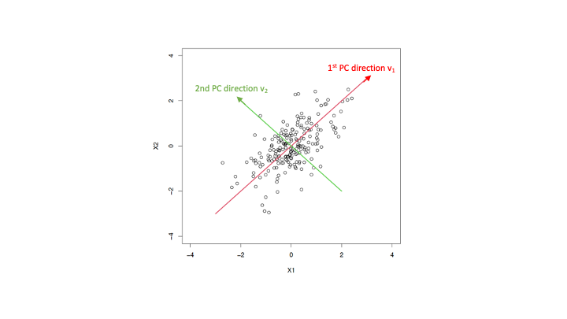

**PCA illustration: $n=200, p-1=2$**

### PCR vs. ridge regression

It can be shown that the *hat matrix* in OLS:
$$\mathbf{H}=\mathbf{X}(\mathbf{X}^T \mathbf{X})^{-}\mathbf{X}^ T=\sum_{j=1}^{rank(\mathbf{X})} u_j u_j^T ,$$
where $u_j$ is the $j$th column of the matrix $\mathbf{U}$ in SVD of $\mathbf{X}$. So the OLS fitted values are:
$$\hat{Y}^{ols}=\mathbf{H} Y = \sum_{j=1}^{rank(\mathbf{X})} (u_j^T Y) u_j ~~~~~~~~~~~~~~(1)$$
Note that $\{u_j^T Y: j=1,\cdots, rank(\mathbf{X}) \}$ are coordinates of $Y$ with respect to the *orthonormal basis* $\{u_j: j=1,\cdots, rank(\mathbf{X})\}$ of the column space of $\mathbf{X}$, $col(\mathbf{X})$.

Similarly, the *smoothing matrix* $\mathbf{S}_\lambda$ in ridge regression:
$$\mathbf{S}_\lambda=\mathbf{X}(\mathbf{X}^T \mathbf{X}+\lambda \mathbf{I})^{-1}\mathbf{X}^ T=\sum_{j=1}^{rank(\mathbf{X})} u_j \frac{d_j^2}{d_j^2+\lambda}u_j^T, ~~~ \lambda > 0$$
So the ridge fitted values are:
$$\hat{Y}^{ridge}_{\lambda}= \mathbf{S}_\lambda Y = \sum_{j=1}^{rank(\mathbf{X})}(\frac{d_j^2}{d_j^2+\lambda} u_j^TY) u_j, ~~~ \lambda > 0~~~~~~(2)$$

Since for $\lambda>0$, the *dampening factor* $0 < \frac{d_j^2}{d_j^2+\lambda}=\frac{1}{1+\frac{\lambda}{d_j^2}}<1$, ridge regression shrinks the coordinates of Y with respect to the orthonormal basis $\{u_j: j=1,\cdots, rank(\mathbf{X})\}$. Moreover, greater amount of shrinkage is applied to the basis vectors with smaller $d_j$ (i.e., increasing index $j$).

In *PCR*, the response Y is regressed to the first $k$ ($1 \leq k \leq rank(\mathbf{X})$) PCs, $z_1,\cdots, z_k$. Since the PCs are orthogonal to each other (and orthogonal to the column of ones due to the centering of $\mathbf{X}$), the estimated coefficient of the $j$th PC $z_j=d_j u_j$ is simply $\hat{\theta}_j=\frac{z_j^T Y}{z_j^T z_j}=\frac{d_j u_j^T Y}{d_j^2}=\frac{u_j^T Y}{d_j}$ and the PCR fitted values are:
$$\hat{Y}^{pcr, k}= \sum_{j=1}^k \hat{\theta}_j z_j =\sum_{j=1}^k (u_j^T Y) u_j,~~~ 1 \leq k \leq rank(\mathbf{X})~~~~(3)$$
So PCR simply conducts a **hard thresholding** (i.e., set to zero) of the coordinates of Y with respect to the basis vectors $\{u_j: j>k\}$. The number of PCs, $k$, is a *tuning parameter* of PCR and needs to be pre-specified or chosen based on some criterion (e.g., through cross-validation). If $k=rank(\mathbf{X})$, then PCR becomes OLS and no form of shrinkage occurs.

## Partial Least Squares Regression (PLSR)

Like *PCR*, **partial least squares regression** constructs a set of linear combinations of the original X variables that are orthogonal to each other and uses this set of variables in place of X in the regression. Unlike $PCR$, in *PLSR*, the construction process involves the response Y: the linear combination coefficients depend on the strength of the corresponding (adjusted) X variable’s univariate effect on Y.

### *PLSR* algorithm

- **Inputs**: centered response vector Y, standardized design matrix $\mathbf{X}$ , an integer $1 \leq k \leq rank(\mathbf{X})$
- **Initialization**: set $\hat{Y}^{(0)}=\mathbf{0}_n$ and $X_j^{(0)}=X_j, ~~j=1,\cdots, p-1$. Here $X_j$ is the $j$th column of the design matrix $\mathbf{X}$, i.e., $X_j$ is the (standardized) observations of the $j$th X variable.
- **Subsequent steps**: For $l=1,2,\cdots, k$

  (a). *PLSR* component: $w_l:= \sum_{j=1}^{p-1} ((X_j^{(l-1)})^T Y) X_j^{(l-1)}$.

  (b). fitted coefficient: $\hat{\theta}_l:=\frac{w_l^T Y}{w_l^T w_l}$.

  (c). fitted values: $\hat{Y}^{(l)}=\hat{Y}^{(l-1)}+\hat{\theta}_l w_l$.

  (d). *Orthogonalization*:
  $$X_j^{(l)}:=X_j^{(l-1)}-\frac{(X_j^{(l-1)})^T w_l}{w_l^T w_l} w_l, ~~~ j=1,\cdots, p-1.$$

  (Note that, $(X_j^{(l)})^T w_l=0, ~j=1,\cdots, p-1$)
- **Outputs**: PLS components $\{w_l: l=1,\cdots, k\}$; their fitted coefficients $\{\hat{\theta}_l: l=1,\cdots, k\}$; the sequence of fitted values $\{\hat{Y}^{(l)}: l=1,\cdots, k\}$.

*Notes:*

- $w_l$’s are centered, i.e., having zero mean.
- $w_l$’s are orthogonal to each other, i.e., $w_l^T w_j=0$ for $l \not= j$. This is due to (a) and (d).
- $w_l$’s are linear combinations of the original X variables with coefficients depending on Y.
- The *PLSR* is **nonlinear** in Y: $\hat{Y}^{plsr}=S_k(Y)Y$.
- It can be shown that, the *PLSR* components have both high variance and high correlation with the response Y.

## PCR and PLSR: Illustration

Let’s look at the `meatspec` data from the `faraway` library. This data has fat content along with 100 channel spectrum of absorbances measured on $215$ meat samples. The goal is to build a model using the absorbance measurements (easy to obtain) to predict the fat content (hard to measure through analytical chemistry).

Let’s first load data and relevant libraries:

```r
library(MASS) #lm.ridge
library(pls)  #pcr, plsr
library(faraway) #data
```

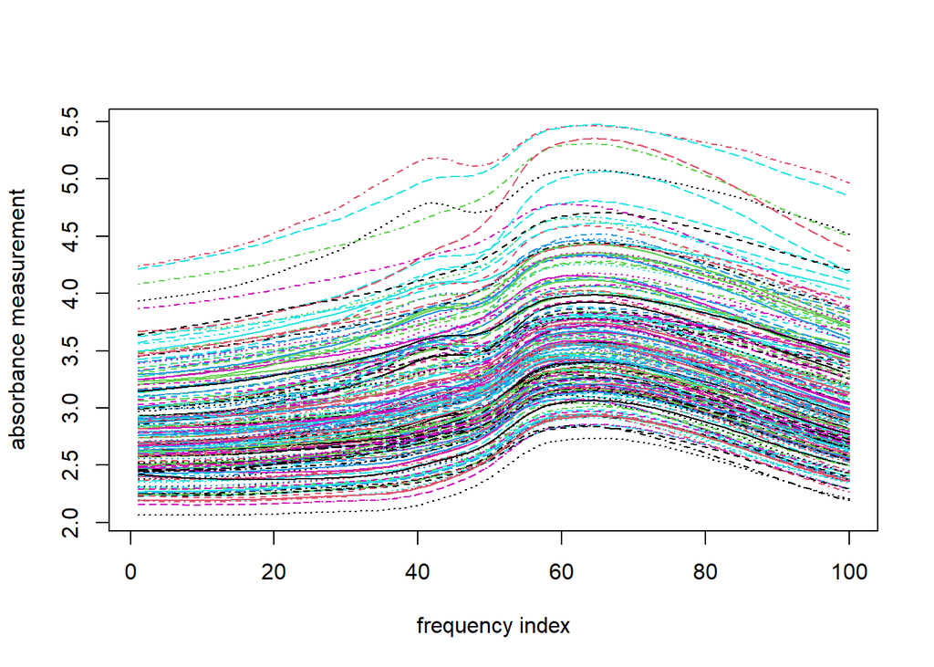

```r
data(meatspec)
matplot(1:100, t(meatspec[,1:100]), xlab="frequency index", ylab="absorbance measurement", type='l')
```

In the “absorbance vs. index” plot, each curve corresponds to one sample. The absorbance measurement is quite smooth with respect to the (frequency) index , i.e., measurements of nearby frequencies are similar. This leads to highly correlated X variables.

Let’s then split data to a training set and a testing set for performance evaluation and methods comparison:

```r
set.seed(1001)  #set seed
index.tr <- sample(nrow(meatspec), 150, replace = FALSE)  ##70% training; 30% testing
train <- meatspec[index.tr, ]
test <- meatspec[-index.tr, ]
```

### PCA

Here, we conduct *PCA* using the `prcomp` function: The argument `center` allows us to center the inputs to have zero mean and the argument `scale` allows us to scale the inputs to have unit variance. Both are recommended. `prcomp` returns a list with the singular values (in `sdev` component), the PC directions/loadings (in `rotation` component), and the PCs (in `x` component).

```r
## pca
meatpca <- prcomp(train[, 1:100], center = TRUE, scale = TRUE)  #standardize X (mean zero, sd 1)
str(meatpca)
```

```
## List of 5
##  $ sdev    : num [1:100] 9.9344 0.9591 0.52 0.3292 0.0775 ...
##  $ rotation: num [1:100, 1:100] -0.0997 -0.0997 -0.0997 -0.0997 -0.0997 ...
##   ..- attr(*, "dimnames")=List of 2
##   .. ..$ : chr [1:100] "V1" "V2" "V3" "V4" ...
##   .. ..$ : chr [1:100] "PC1" "PC2" "PC3" "PC4" ...
##  $ center  : Named num [1:100] 2.81 2.81 2.81 2.81 2.82 ...
##   ..- attr(*, "names")= chr [1:100] "V1" "V2" "V3" "V4" ...
##  $ scale   : Named num [1:100] 0.431 0.433 0.436 0.439 0.441 ...
##   ..- attr(*, "names")= chr [1:100] "V1" "V2" "V3" "V4" ...
##  $ x       : num [1:150, 1:100] -11.98 -3.32 -14.47 14.18 11.95 ...
##   ..- attr(*, "dimnames")=List of 2
##   .. ..$ : chr [1:150] "87" "163" "79" "48" ...
##   .. ..$ : chr [1:100] "PC1" "PC2" "PC3" "PC4" ...
##  - attr(*, "class")= chr "prcomp"
```

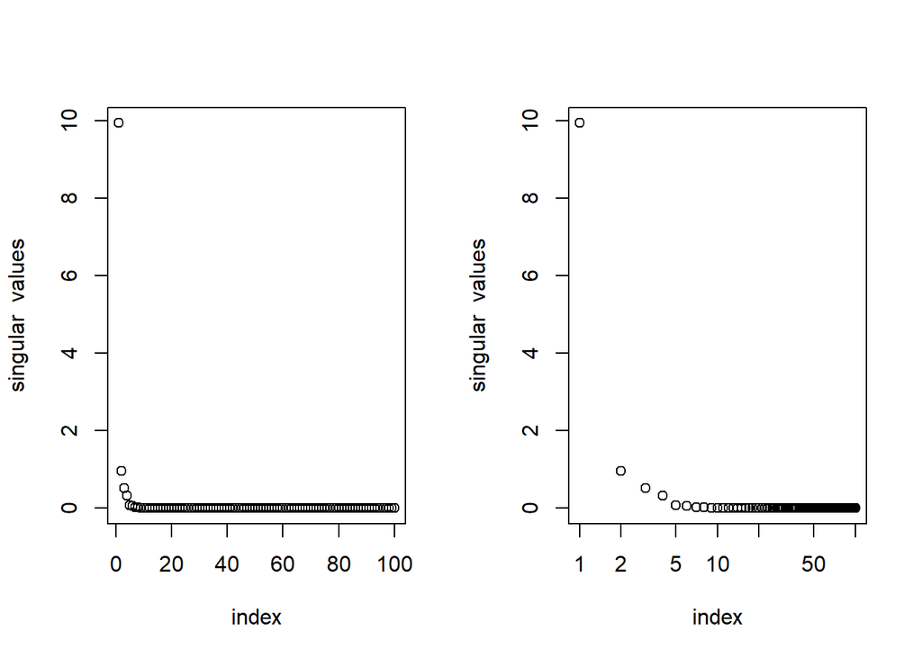

```r
# scree plot: index plot of the singular values
par(mfrow = c(1, 2))
plot(meatpca$sdev, type = "p", xlab = "index", ylab = "singular  values")
plot(meatpca$sdev, type = "p", xlab = "index", ylab = "singular  values", log = "x")  # two elbows: 2 and 5
```

```r
cumsum((meatpca$sdev)^2)/sum((meatpca$sdev)^2)  #cumulative percentage of variance explained by the PCs
```

```
##   [1] 0.9869170 0.9961158 0.9988200 0.9999037 0.9999637 0.9999885 0.9999949
##   [8] 0.9999986 0.9999992 0.9999996 0.9999998 0.9999999 0.9999999 1.0000000
##  [15] 1.0000000 1.0000000 1.0000000 1.0000000 1.0000000 1.0000000 1.0000000
##  [22] 1.0000000 1.0000000 1.0000000 1.0000000 1.0000000 1.0000000 1.0000000
##  [29] 1.0000000 1.0000000 1.0000000 1.0000000 1.0000000 1.0000000 1.0000000
##  [36] 1.0000000 1.0000000 1.0000000 1.0000000 1.0000000 1.0000000 1.0000000
##  [43] 1.0000000 1.0000000 1.0000000 1.0000000 1.0000000 1.0000000 1.0000000
##  [50] 1.0000000 1.0000000 1.0000000 1.0000000 1.0000000 1.0000000 1.0000000
##  [57] 1.0000000 1.0000000 1.0000000 1.0000000 1.0000000 1.0000000 1.0000000
##  [64] 1.0000000 1.0000000 1.0000000 1.0000000 1.0000000 1.0000000 1.0000000
##  [71] 1.0000000 1.0000000 1.0000000 1.0000000 1.0000000 1.0000000 1.0000000
##  [78] 1.0000000 1.0000000 1.0000000 1.0000000 1.0000000 1.0000000 1.0000000
##  [85] 1.0000000 1.0000000 1.0000000 1.0000000 1.0000000 1.0000000 1.0000000
##  [92] 1.0000000 1.0000000 1.0000000 1.0000000 1.0000000 1.0000000 1.0000000
##  [99] 1.0000000 1.0000000
```

The *scree plot* shows two “elbows”, 2 and 5, around which the singular value drops rapidly. This indicates that the first 5 PCs will be able to explain most of the variation in the data (99.99637%).

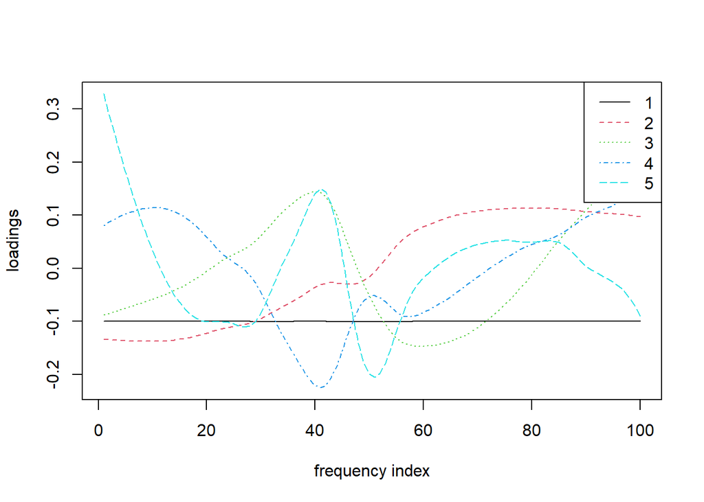

```r
par(mfrow=c(1,1))
#plot PC directions/loadings that generate the first five principal components against the X index (frequency index)
matplot(1:100, meatpca$rotation[,1:5], type='l', xlab="frequency index", ylab="loadings")
legend('topright', legend=1:5, lty=1:5, col=1:5)
```

```r
summary(meatpca$rotation[,1]) ##loadings of the 1st PC: almost constant
```

```
##     Min.  1st Qu.   Median     Mean  3rd Qu.     Max.
## -0.10059 -0.10011 -0.10001 -0.10000 -0.09984 -0.09953
```

The 1st PC direction/loadings are near constant across the X index (frequency index), indicating that the 1st PC represents the sum of the X variables (i.e., the overall absorbance level). The 2nd PC directions/loadings have opposite signs for small frequency indices and for large frequency indices, indicating the 2nd PC represents a contrast between higher and lower frequencies.

### Fit *PCR* and *PLSR*

We can fit *PCR* by the `pcr` function in the `pls` library: The arguments `center` and `scale` specify whether X and Y should be centered to have zero mean and whether X should be scaled to have unit variance, respectively; The argument `ncomp` specifies the number of components to be considered: If not supplied, the maximum number of components is used (i.e., $rank(\mathbf{X})$). Note that fitted values and fitted coefficients (of X variables) of `all` successive models will be returned; The argument `validation` specifies how validation should be conducted (default: “none”): For `validation="CV"`, the default is to conduct **10-fold cross validation** with random splits; The `segments` and `segment.type` arguments specify CV folds and how segments are created.

For illustration purpose, let’s fit *PCR* up to the maximum number of components (here the number of X variables: 100):

```r
k.max <- 100
# fit models with 1,2,.., k.max components successively; standardize X and center
# Y; conduct 'CV' (5 folds, consecutive segments) fitted values and coefficients
# (of the standardized X) of these k.max models are returned;
meat.pcr <- pcr(fat ~ ., data = train, ncomp = k.max, center = TRUE, scale = TRUE,
    validation = "CV", segments = 5, segment.type = "consecutive")
str(meat.pcr, list.len = 10)
```

```
## List of 19
##  $ coefficients : num [1:100, 1, 1:100] 0.066 0.066 0.066 0.066 0.066 ...
##   ..- attr(*, "dimnames")=List of 3
##   .. ..$ : chr [1:100] "V1" "V2" "V3" "V4" ...
##   .. ..$ : chr "fat"
##   .. ..$ : chr [1:100] "1 comps" "2 comps" "3 comps" "4 comps" ...
##  $ scores       : 'scores' num [1:150, 1:100] -11.98 -3.32 -14.47 14.18 11.95 ...
##   ..- attr(*, "dimnames")=List of 2
##   .. ..$ : chr [1:150] "87" "163" "79" "48" ...
##   .. ..$ : chr [1:100] "Comp 1" "Comp 2" "Comp 3" "Comp 4" ...
##  $ loadings     : 'loadings' num [1:100, 1:100] -0.0997 -0.0997 -0.0997 -0.0997 -0.0997 ...
##   ..- attr(*, "dimnames")=List of 2
##   .. ..$ : chr [1:100] "V1" "V2" "V3" "V4" ...
##   .. ..$ : chr [1:100] "Comp 1" "Comp 2" "Comp 3" "Comp 4" ...
##  $ Yloadings    : 'loadings' num [1, 1:100] -0.663 3.265 14.978 -20.3 37.817 ...
##   ..- attr(*, "dimnames")=List of 2
##   .. ..$ : chr "fat"
##   .. ..$ : chr [1:100] "Comp 1" "Comp 2" "Comp 3" "Comp 4" ...
##  $ projection   : num [1:100, 1:100] -0.0997 -0.0997 -0.0997 -0.0997 -0.0997 ...
##   ..- attr(*, "dimnames")=List of 2
##   .. ..$ : chr [1:100] "V1" "V2" "V3" "V4" ...
##   .. ..$ : chr [1:100] "Comp 1" "Comp 2" "Comp 3" "Comp 4" ...
##  $ Xmeans       : Named num [1:100] 6.51 6.48 6.45 6.41 6.38 ...
##   ..- attr(*, "names")= chr [1:100] "V1" "V2" "V3" "V4" ...
##  $ Ymeans       : Named num 18.8
##   ..- attr(*, "names")= chr "fat"
##  $ fitted.values: num [1:150, 1, 1:100] 26.74 21 28.39 9.41 10.89 ...
##   ..- attr(*, "dimnames")=List of 3
##   .. ..$ : chr [1:150] "87" "163" "79" "48" ...
##   .. ..$ : chr "fat"
##   .. ..$ : chr [1:100] "1 comps" "2 comps" "3 comps" "4 comps" ...
##  $ residuals    : num [1:150, 1, 1:100] -15.04 -2.2 -18.29 -8.51 -3.19 ...
##   ..- attr(*, "dimnames")=List of 3
##   .. ..$ : chr [1:150] "87" "163" "79" "48" ...
##   .. ..$ : chr "fat"
##   .. ..$ : chr [1:100] "1 comps" "2 comps" "3 comps" "4 comps" ...
##  $ Xvar         : Named num [1:100] 1.47e+04 1.37e+02 4.03e+01 1.61e+01 8.94e-01 ...
##   ..- attr(*, "names")= chr [1:100] "Comp 1" "Comp 2" "Comp 3" "Comp 4" ...
##   [list output truncated]
##  - attr(*, "class")= chr "mvr"
```

```r
meat.pcr$validation$method  ##validation method
```

```
## [1] "CV"
```

```r
dim(meat.pcr$fitted.values)  ##fitted values for 1,.., k.max compoents models: 150 x 1 x 100
```

```
## [1] 150   1 100
```

```r
dim(predict(meat.pcr))  ##equivalently: 150 x 1 x 100
```

```
## [1] 150   1 100
```

```r
dim(predict(meat.pcr, ncomp = 5))  ## fitted values for the 5-component model
```

```
## [1] 150   1   1
```

We can fit *PCR* directly by regressing the response Y to the PCs, which gives identical results as using the `pcr` function:

```r
my.pcr <- lm(train$fat ~ meatpca$x[, 1:5])
summary(abs(fitted(my.pcr) - predict(meat.pcr, ncomp = 5)))  #identical results
```

```
##      Min.   1st Qu.    Median      Mean   3rd Qu.      Max.
## 0.000e+00 1.066e-14 1.776e-14 2.460e-14 3.553e-14 1.119e-13
```

Similarly, we can fit *PLSR* by the `plsr` function in the `pls` library:

```r
meat.plsr <- plsr(fat ~ ., data = train, ncomp = k.max, center = TRUE, scale = TRUE,
    validation = "CV", segments = 5, segment.type = "consecutive")
```

### Choose the number of components by *CV plot*

We can use *cross validation* to choose the number of components for the *PCR* and *PLSR* models. Let’s look at the *CV plot* by the `validationplot` function:

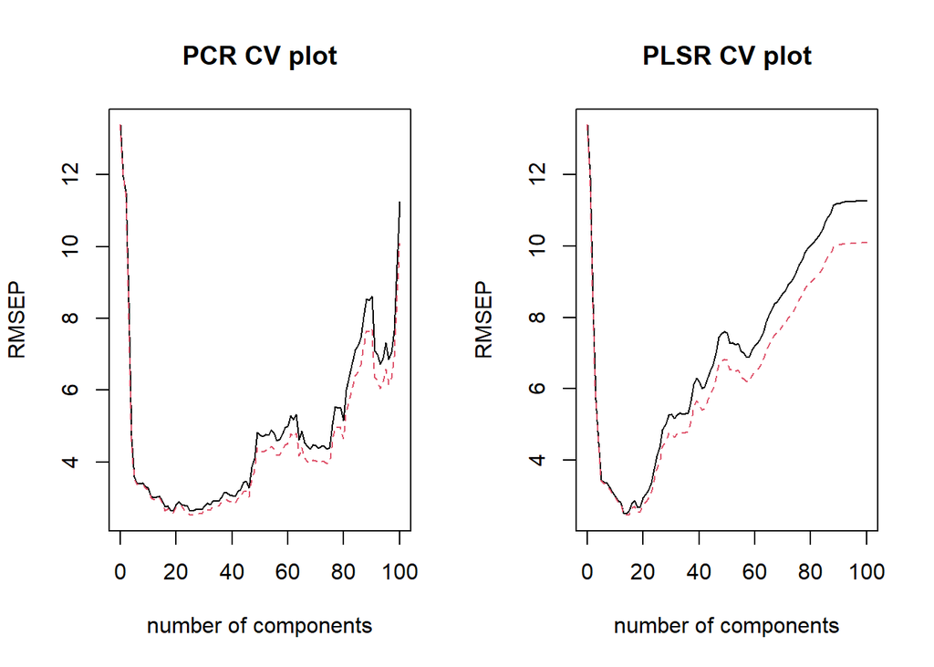

```r
par(mfrow = c(1, 2))
validationplot(meat.pcr, main = "PCR CV plot")
validationplot(meat.plsr, main = "PLSR CV plot")
```

```r
mfrow = c(1, 1)
```

These plots suggest that using 15 components is a reasonable choice for *PCR* and *PLSR* on this data, whereas using 5 components (suggested by the *PCA scree plot*) is likely to have worse performance.

### Look at the fitted coefficients

Let’s fit *OLS* and *ridge* as well for comparison purpose:

```r
## ols
meat.ols <- lm(fat ~ ., data = train)
# ridge
meat.ridge <- lm.ridge(fat ~ ., data = train, lambda = seq(0, 1e-07, 1e-09))
```

We can compare the fitted coefficients (of the X variables) by these models. Note that, the coefficients returned by `pcr` and `plsr` are for the standardized X variables. In order to get the coefficients for the original X variable, we need to divide them by the scales stored in the `scale` component (similarly for the `ridge` coefficients):

```r
## check length
length(coefficients(meat.ols))  ##OLS: 101: including the intercept
```

```
## [1] 101
```

```r
length(coefficients(meat.pcr, ncomp = 5))  ##PCR: 100: no intercept due to centering;
```

```
## [1] 100
```

```r
length(coefficients(meat.plsr, ncomp = 5))  ##PLSR: 100: no intercept due to centering;
```

```
## [1] 100
```

```r
## check scales
summary(meat.pcr$scale)  ##PCR and PLSR default scales: sample standard deviation
```

```
##    Min. 1st Qu.  Median    Mean 3rd Qu.    Max.
##  0.4309  0.5080  0.5616  0.5358  0.5661  0.5778
```

```r
summary(meat.plsr$scale)
```

```
##    Min. 1st Qu.  Median    Mean 3rd Qu.    Max.
##  0.4309  0.5080  0.5616  0.5358  0.5661  0.5778
```

```r
summary(apply(train[, 1:100], 2, sd))
```

```
##    Min. 1st Qu.  Median    Mean 3rd Qu.    Max.
##  0.4309  0.5080  0.5616  0.5358  0.5661  0.5778
```

```r
summary(meat.ridge$scales)  ## ridge default scales: \sqrt(\sum (x_i-\bar{x})^2/n) =sd*\sqrt{(n-1)/n}
```

```
##    Min. 1st Qu.  Median    Mean 3rd Qu.    Max.
##  0.4294  0.5063  0.5597  0.5340  0.5642  0.5758
```

```r
n = nrow(train)
summary(apply(train[, 1:100], 2, sd) * sqrt((n - 1)/n))
```

```
##    Min. 1st Qu.  Median    Mean 3rd Qu.    Max.
##  0.4294  0.5063  0.5597  0.5340  0.5642  0.5758
```

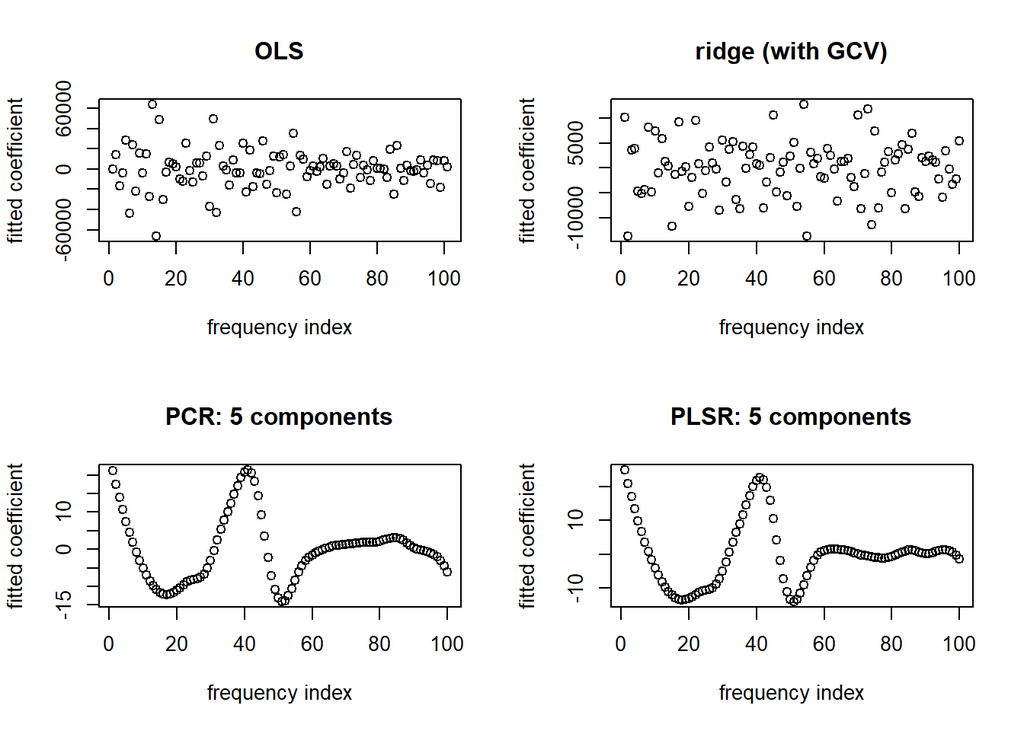

```r
## plot fitted coefficients
par(mfrow = c(2, 2))
plot(coefficients(meat.ols), xlab = "frequency index", ylab = "fitted coefficient",
    main = "OLS")
plot(meat.ridge$coef[, which.min(meat.ridge$GCV)]/meat.ridge$scales, xlab = "frequency index",
    ylab = "fitted coefficient", main = "ridge (with GCV)")
plot(coefficients(meat.pcr, ncomp = 5)/meat.pcr$scale, xlab = "frequency index",
    ylab = "fitted coefficient", main = "PCR: 5 components")
plot(coefficients(meat.plsr, ncomp = 5)/meat.plsr$scale, xlab = "frequency index",
    ylab = "fitted coefficient", main = "PLSR: 5 components")
```

```r
par(mfrow = c(1, 1))
```

The *PCR* and *PLSR* fitted coefficients are quite similar and are much smaller in magnitude than those of the *OLS* and *ridge*. Moreover, the *PCR* and *PLSR* fitted coefficients are quite smooth with respect to the frequency index (i.e., variables corresponding to nearby frequencies have similar coefficients). However, this is not the case for *OLS* and *ridge* (with *GCV* selected $\lambda$).

We can also use the `coefplot` function to plot the fitted coefficients (for the standardized X variables) of the *PLSR* and *PCR* models:

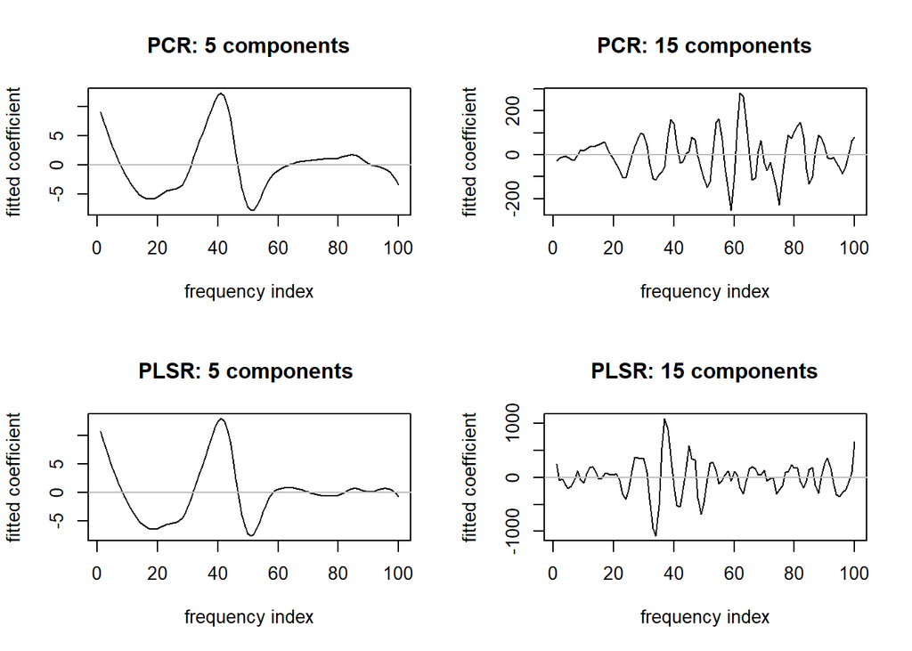

```r
par(mfrow = c(2, 2))
coefplot(meat.pcr, ncomp = 5, xlab = "frequency index", ylab = "fitted coefficient",
    main = "PCR: 5 components")
coefplot(meat.pcr, ncomp = 15, xlab = "frequency index", ylab = "fitted coefficient",
    main = "PCR: 15 components")
coefplot(meat.plsr, ncomp = 5, xlab = "frequency index", ylab = "fitted coefficient",
    main = "PLSR: 5 components ")
coefplot(meat.plsr, ncomp = 15, xlab = "frequency index", ylab = "fitted coefficient",
    main = "PLSR: 15 components")
```

```r
par(mfrow = c(1, 1))
```

As expected, with larger number of components, the fitted coefficients of *PCR* and *PLSR* become less smooth.

With $100$ components (i.e., the number of X variables), *PCR* and *PLSR* become *OLS*:

```r
## fitted values: absolute difference
summary(abs(meat.ols$fitted.values - predict(meat.pcr, ncomp = 100)))
```

```
##      Min.   1st Qu.    Median      Mean   3rd Qu.      Max.
## 5.471e-13 2.087e-11 5.436e-11 7.591e-11 1.093e-10 4.609e-10
```

```r
summary(abs(meat.ols$fitted.values - predict(meat.plsr, ncomp = 100)))
```

```
##      Min.   1st Qu.    Median      Mean   3rd Qu.      Max.
## 7.147e-09 2.820e-07 6.922e-07 9.330e-07 1.399e-06 3.741e-06
```

```r
## fitted coefficients: relative difference
summary(abs(coefficients(meat.ols)[-1] - coefficients(meat.pcr, ncomp = 100)/meat.pcr$scale)/abs(coefficients(meat.ols)[-1]))
```

```
##      Min.   1st Qu.    Median      Mean   3rd Qu.      Max.
## 9.610e-12 1.153e-10 2.719e-10 1.881e-09 6.578e-10 1.149e-07
```

```r
summary(abs(coefficients(meat.ols)[-1] - coefficients(meat.plsr, ncomp = 100)/meat.plsr$scale)/abs(coefficients(meat.ols)[-1]))
```

```
##      Min.   1st Qu.    Median      Mean   3rd Qu.      Max.
## 6.440e-08 1.603e-06 3.284e-06 2.935e-05 7.067e-06 1.822e-03
```

### Performance evaluation

Let’s now compare *RMSPE* of these models on the testing set:

```r
rmspe <- function(y, yh) sqrt(mean((y - yh)^2))

## OLS
c(rmspe(train$fat, meat.ols$fitted.values), rmspe(test$fat, predict(meat.ols, test)))
```

```
## [1] 0.7339363 4.1781203
```

```r
## ridge:
coef.GCV = meat.ridge$coef[, which.min(meat.ridge$GCV)]
X.train = scale(train[, 1:100], center = meat.ridge$xm, scale = meat.ridge$scales)
Yh.train = X.train %*% coef.GCV + meat.ridge$ym
X.test = scale(test[, 1:100], center = meat.ridge$xm, scale = meat.ridge$scales)
Yh.test = X.test %*% coef.GCV + meat.ridge$ym
c(rmspe(train$fat, Yh.train), rmspe(test$fat, Yh.test))
```

```
## [1] 0.9450213 2.9668577
```

```r
## PCR: 5 and 15 components
c(rmspe(train$fat, predict(meat.pcr, ncomp = 5)), rmspe(test$fat, predict(meat.pcr,
    test, ncomp = 5)))
```

```
## [1] 3.319909 2.850757
```

```r
c(rmspe(train$fat, predict(meat.pcr, ncomp = 15)), rmspe(test$fat, predict(meat.pcr,
    test, ncomp = 15)))
```

```
## [1] 2.482397 2.144211
```

```r
## PLSR: 5 and 15 components
c(rmspe(train$fat, predict(meat.plsr, ncomp = 5)), rmspe(test$fat, predict(meat.plsr,
    test, ncomp = 5)))
```

```
## [1] 3.172375 2.665281
```

```r
c(rmspe(train$fat, predict(meat.plsr, ncomp = 15)), rmspe(test$fat, predict(meat.plsr,
    test, ncomp = 15)))
```

```
## [1] 1.916111 2.268362
```

*PCR* and *PLSR* with 5 components (*scree plot* suggested number) perform quite decently and similarly as *ridge* with *GCV* selected $\lambda$. With 15 components (*CV* suggested number), *PCR* and *PLSR* perform better. Moreover, unlike *OLS* and *ridge*, the *RMSPE* of *PCR* and *PLSR* is not very different on the training set and on the testing set, indicating little overfitting of these two models when the number of components is kept small.

The effective number of X variables in the *ridge* model with *GCV* selected $\lambda$ is 66, which is still quite large and explains why the *ridge* model overfits the training set:

```r
lambda.GCV = meat.ridge$lambda[which.min(meat.ridge$GCV)]
S = X.train %*% solve(t(X.train) %*% X.train + lambda.GCV * diag(100), t(X.train))  ## the smoothing matrix
sum(diag(S))  ## effective number of X variables of the ridge model with GCV chosen lambda
```

```
## [1] 66.44607
```